# Model selection

Simona Kolarova

# Aims

- Compare the predictive performance of 4 machine learning models (i.e., Logistic regression, Random forest, Support vector machines and Neutral networks) on the phase bahaviour data
- Compare the predictive performance of the models on 2 phase behaviour datasets, in which the phase behaviour is classified at every vertex in a phase diagram with a grid of 5 pc (94 datapoints per phase diagram) or a grid of 2.5 pc (407 datapoints per phase diagram).

# Sources

## Libraries

```r
library(tidyverse)
library(caret)
library(randomForest)
library(kernlab)
library(nnet)
library(pROC)
library(doParallel)
```

## R script sources

```r
source("Machine learning algorithms.R", local = knitr::knit_global())
source("Predictive performance assessment.R", local = knitr::knit_global())
source("Statistical analysis.R", local = knitr::knit_global())
```

## Parallel processing

```r
registerDoParallel(makeCluster(detectCores() - 1))
```

## Datasets

```r
PB_predictors_25pc_step <- read.csv("Data/Phase behaviour and descriptors (25 pc step).csv")
PB_predictors_5pc_step <- read.csv("Data/Phase behaviour and descriptors (5 pc step).csv")
```

### Datasets splitting

Both datasets were split into 2 training/testing(`TT_data`) and validation (`V_data`) datasets comprising the same 21 and 7 phase diagrams, respectively.

```r
TT_data_25pc_step <- filter(PB_predictors_25pc_step, Set == "Training")
V_data_25pc_step <- filter(PB_predictors_25pc_step, Set == "Validation")

TT_data_5pc_step <- filter(PB_predictors_5pc_step, Set == "Training")
V_data_5pc_step <- filter(PB_predictors_5pc_step, Set == "Validation")
```

### Dataset predictor and class level definition

```r
predictors_all <- colnames(TT_data_25pc_step[, 3:66][, -(4:6)])

TT_data_25pc_step$Phase.behaviour <- factor(as.character(TT_data_25pc_step$Phase.behaviour))
V_data_25pc_step$Phase.behaviour <- factor(as.character(V_data_25pc_step$Phase.behaviour))

TT_data_5pc_step$Phase.behaviour <- factor(as.character(TT_data_5pc_step$Phase.behaviour))
V_data_5pc_step$Phase.behaviour <- factor(as.character(V_data_5pc_step$Phase.behaviour))
```

# Predictive modelling

## Global parameters

*Summary* and a *training control* ('trainCtrl') functions to allow the uniform training and evaluation of the models.

```r
PMsummary <- function(...) c(twoClassSummary(...), defaultSummary(...))
trainCtrl <- trainControl(method = "cv", number = 10, summaryFunction = PMsummary,
    classProbs = TRUE, savePredictions = TRUE)
```

## Model training and evalution for 2.5 % step phase behaviour dataset

```r
for (i in 1:20) {
    model_performance_25pc_step <- run_logistic_regression(TT_data_25pc_step, V_data_25pc_step,
        predictors_all, model_performance_25pc_step, "Logistic regression", i)
}
```

```r
for (i in 21:40) {
    model_performance_25pc_step <- run_random_forest(TT_data_25pc_step, V_data_25pc_step,
        predictors_all, model_performance_25pc_step, "Random forest", i)
}
```

```r
for (i in 41:60) {
    model_performance_25pc_step <- run_support_vector_machines(TT_data_25pc_step,
        V_data_25pc_step, predictors_all, model_performance_25pc_step, "Support vector machines",
        i)
}
```

```r
for (i in 61:80) {
    model_performance_25pc_step <- run_neural_network(TT_data_25pc_step, V_data_25pc_step,
        predictors_all, model_performance_25pc_step, "Neural network", i)
}
```

## Model training and evalution for 5 % step phase behaviour dataset

```r
for (i in 1:20) {
    model_performance_5pc_step <- run_logistic_regression(TT_data_5pc_step, V_data_5pc_step,
        predictors_all, model_performance_5pc_step, "Logistic regression", i)
}
```

```r
for (i in 21:40) {
    model_performance_5pc_step <- run_random_forest(TT_data_5pc_step, V_data_5pc_step,
        predictors_all, model_performance_5pc_step, "Random forest", i)
}
```

```r
for (i in 41:60) {
    model_performance_5pc_step <- run_support_vector_machines(TT_data_5pc_step, V_data_5pc_step,
        predictors_all, model_performance_5pc_step, "Support vector machines", i)
}
```

```r
for (i in 61:80) {
    model_performance_5pc_step <- run_neural_network(TT_data_5pc_step, V_data_5pc_step,
        predictors_all, model_performance_5pc_step, "Neural network", i)
}
```

## Comparison of model performance metrics

### Visial comparison

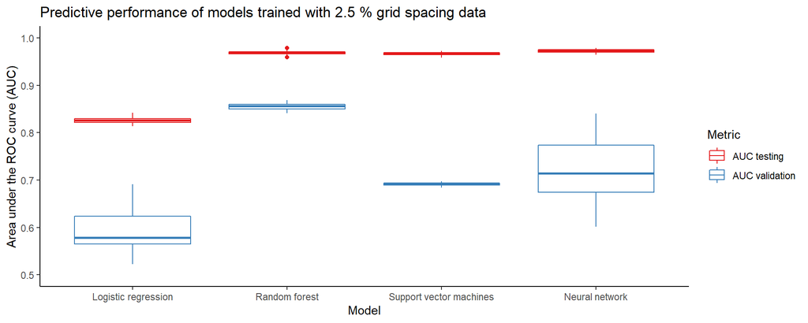

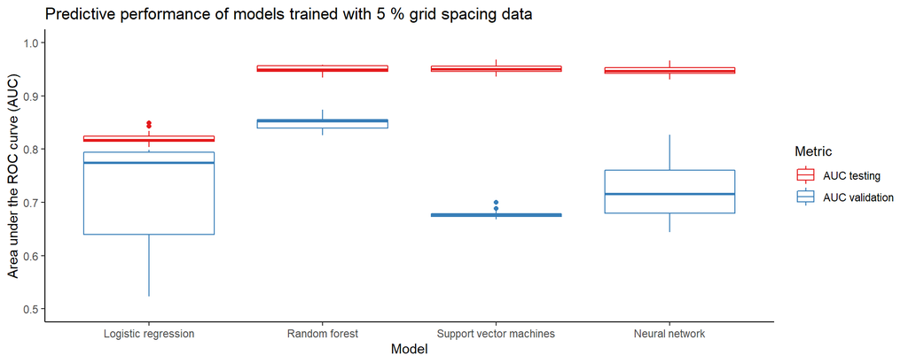

### Statistical comparison

```
## Comparison of AUC testing values for models trained with 2.5 % grid spacing data
```

```
## Data normally distributed.
## Homogeneity of variance assumption not met.
## One-way Welch test: There are significant differences between the groups.
```

```
##
##  Pairwise comparisons using t tests with non-pooled SD
##
## data:  dep_variable and ind_variable
##
##                         Logistic regression Neural network Random forest
## Neural network          < 2e-16             -              -
## Random forest           < 2e-16             0.016          -
## Support vector machines < 2e-16             1.8e-06        0.018
##
## P value adjustment method: BH
```

```
## Comparison of AUC validation values for models trained with 2.5 % grid spacing data
```

```
## Data not normally distributed.
## Kruskal-Wallis rank sum test: There are significant differences between the groups.
```

```
##
##  Pairwise comparisons using Wilcoxon rank sum test with continuity correction
##
## data:  dep_variable and ind_variable
##
##                         Logistic regression Neural network Random forest
## Neural network          2.8e-06             -              -
## Random forest           1.4e-07             1.4e-07        -
## Support vector machines 6.8e-07             0.096          1.4e-07
##
## P value adjustment method: BH
```

```
## Comparison of AUC testing values for models trained with 5 % grid spacing data
```

```
## Data normally distributed.
## Variance comparable across groups.
## One-way ANOVA test: There are significant differences between the groups.
```

```
##   Tukey multiple comparisons of means
##     95% family-wise confidence level
##
## Fit: aov(formula = dep_variable ~ ind_variable, data = data)
##
## $ind_variable
##                                                    diff          lwr
## Neural network-Logistic regression          0.125460208  0.118052476
## Random forest-Logistic regression           0.127713754  0.120306022
## Support vector machines-Logistic regression 0.129135194  0.121727462
## Random forest-Neural network                0.002253545 -0.005154187
## Support vector machines-Neural network      0.003674986 -0.003732746
## Support vector machines-Random forest       0.001421441 -0.005986292
##                                                     upr     p adj
## Neural network-Logistic regression          0.132867941 0.0000000
## Random forest-Logistic regression           0.135121486 0.0000000
## Support vector machines-Logistic regression 0.136542926 0.0000000
## Random forest-Neural network                0.009661277 0.8546088
## Support vector machines-Neural network      0.011082718 0.5637992
## Support vector machines-Random forest       0.008829173 0.9578814
```

```
## Comparison of AUC validation values for models trained with 5 % grid spacing data
```

```
## Data not normally distributed.
## Kruskal-Wallis rank sum test: There are significant differences between the groups.
```

```
##
##  Pairwise comparisons using Wilcoxon rank sum test with continuity correction
##
## data:  dep_variable and ind_variable
##
##                         Logistic regression Neural network Random forest
## Neural network          0.617               -              -
## Random forest           1.6e-07             1.6e-07        -
## Support vector machines 0.038               0.014          1.6e-07
##
## P value adjustment method: BH
```

Overall, the random forest model was observed to have a statistically significantly better predictive performance on the validatation datasets (both for phase behaviour data with 2.5% or 5% spacing) than the Logistic regression, Support vector machines and Neural network models and, hence, was carried forward.

## Comparison of random forest model predictive performance on phase behaviour data with 2.5% or 5% grid spacing

### Visial comparison

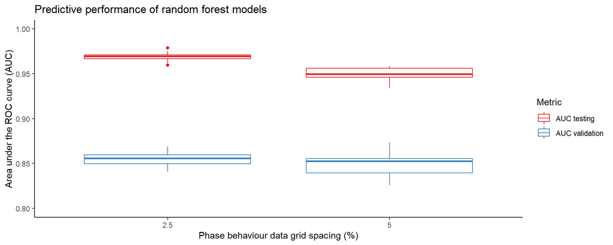

### Statistical comparison

```
## Comparison of AUC testing values for random forest models
```

```
## Data normally distributed.
## Variance comparable across groups.
## One-way ANOVA test: There are significant differences between the groups.
```

```
##   Tukey multiple comparisons of means
##     95% family-wise confidence level
##
## Fit: aov(formula = dep_variable ~ ind_variable, data = data)
##
## $ind_variable
##             diff         lwr         upr p adj
## 5-2.5 -0.0198828 -0.02373234 -0.01603326     0
```

```
## Comparison of AUC validation values for random forest models
```

```
## Data normally distributed.
## Homogeneity of variance assumption not met.
## One-way Welch test: There are no significant differences between the groups.
```

The predictive performance of the random forest model on the testing phase behaviour data obtained using a 2.5 % grid spacing is statistically significantly better than that on the testing phase behaviour data obtained using a 5 % grid spacing, and, hence this dataset was carried forward.

# Export results

```r
write.csv(model_performance_25pc_step, "Results/Model performance (2.5 pc step).csv",
    row.names = FALSE)
write.csv(model_performance_5pc_step, "Results/Model performance (5 pc step).csv",
    row.names = FALSE)
```